# BCCIO / PDAC Comparison

Load Packages and Data

```r
memory.limit(size = 16000000)
```

```
[1] 1.6e+07
```

Merge PDAC and BCC datasets (subset)

```r
save(bcc.pdac.merge, "C:\\Users\\Ryan\\Documents\\Nie Research Project\\BCC.PDAC.merge")
```

```
Error in save(bcc.pdac.merge, "C:\\Users\\Ryan\\Documents\\Nie Research Project\\BCC.PDAC.merge") :
  object ‘C:\Users\Ryan\Documents\Nie Research Project\BCC.PDAC.merge’ not found
```

Enhanced Volcano Plots (PDAC vs. BCC)

Enhanced Volcano Plots (PDAC)

```r
pdac.macrophage.markers <- FindMarkers(PDAC155698.integrated, subset.ident='Macrophages', group.by='orig.ident', ident.1='PDAC155698.1')
```

[output not shown]

[output not shown]

[output cut: 35 more lines]

[output not shown]

```r
pdac.macrophage.markers_tibble <- as_tibble(pdac.macrophage.markers, rownames = "GeneNames")
pdac.macrophage.markers_tibble <- arrange(pdac.macrophage.markers_tibble, avg_logFC)

pdac.macrophage.volcano <- EnhancedVolcano(pdac.macrophage.markers_tibble,
                               lab = pdac.macrophage.markers_tibble$GeneNames,
                               x = 'avg_logFC', y = 'p_val_adj',
                               pCutoff = 0.05, FCcutoff = 0.5,
                               title= 'Macrophage DE: PDAC Patient 1 vs. Rest of Patients')
```

```
One or more p-values is 0. Converting to 10^-1 * current lowest non-zero p-value...
```

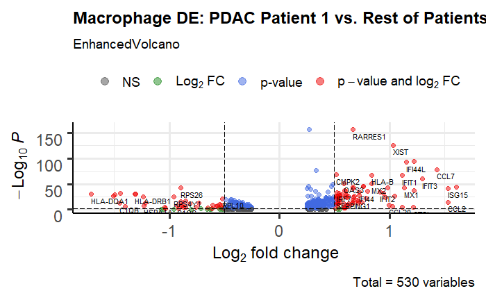

```r
pdac.macrophage.volcano
```

Compare BCC Responders vs. Nonresponders

Look specifically at BCC pre-treatment Goal: Determine predictors of PD1-blockade responsiveness

```r
interestingcelltypes <- c("CD8_memory", "CD8_activation", "CD8_exhausted", "CD4", "Tregs", "T_proliferation", "B cells", "Macrophages")

Idents(BCCIO.pre) <- BCCIO.pre$seurat_clusters

for(celltype in interestingcelltypes) {
  bcc.pretreatment.responder.volcano <- bioc_volcano(BCCIO.pre, celltype, c("response"), c("Responsive"), c("Nonresponsive"))
  assign(paste0("bcc.pretreatment.", celltype, ".responder.volcano"), bcc.pretreatment.responder.volcano)
  bcc.pretreatment.responder.volcano
}
```

[output not shown]

[output cut: 622 more lines]

[output not shown]

Use Gene Ontology to investigate markers and gene pathways

```r
macrophage.markers <- FindMarkers(BCCIO.pre, subset.ident='Macrophages', group.by='response', ident.1='Responsive')
```

```
Error in FindMarkers(BCCIO.pre, subset.ident = "Macrophages", group.by = "response",  :
  object 'BCCIO.pre' not found
```

Merge BCC pretreatment data with PDAC data

```r
BCCIO.pre@meta.data$cell.names <- rownames(BCCIO.pre@meta.data)
```

```
Error in rownames(BCCIO.pre@meta.data) : object 'BCCIO.pre' not found
```

Enhanced Volcano plots for BCC pretreatment (responder) vs. PDAC

```r
bcc.pre.responders.pdac.merge <- subset(bcc.pre.pdac.merge, idents = c("PDAC", "Responsive"))
```

```
Error in WhichCells.Seurat(object = x, cells = cells, idents = idents,  :
  Cannot find the following identities in the object: PDACResponsive
```

Enhanced Volcano plots for PDAC by patient vs. BCC responders

```r
Idents(bcc.pre.responders.pdac.merge) <- bcc.pre.responders.pdac.merge$pdac.patient
```

```
Error: Cannot find 'pdac.patient' in this Seurat object
```

Check DE gene expression of HLA genes by patient

```r
bcc.pdac.subsets <- list(bcc.pdac.1, bcc.pdac.2, bcc.pdac.3, bcc.pdac.4, bcc.pdac.5, bcc.pdac.6, bcc.pdac.7, bcc.pdac.8, bcc.pdac.9, bcc.pdac.10, bcc.pdac.11A, bcc.pdac.11B, bcc.pdac.12, bcc.pdac.13, bcc.pdac.15, bcc.pdac.16)

bcc.pdac.markers <- lapply(bcc.pdac.subsets, function(i) bioc_markers(i, c("Macrophages"), c("pdac.patient"), c("BCC"), pCutoff = 1, FCcutoff = 0.01))
```

[output not shown]

[output cut: 1563 more lines]

[output not shown]

```r
for (i in 1:length(bcc.pdac.markers)) {
  assign(paste0("bcc.pdac.", i, ".markers"), bcc.pdac.markers[[i]])
}

bcc.pdac.11A.markers <- bcc.pdac.11.markers
bcc.pdac.11B.markers <- bcc.pdac.12.markers
bcc.pdac.12.markers <- bcc.pdac.13.markers
bcc.pdac.13.markers <- bcc.pdac.14.markers

## Segregate the HLA genes

bcc.pdac.markers <- list(bcc.pdac.1.markers, bcc.pdac.2.markers, bcc.pdac.3.markers, bcc.pdac.4.markers, bcc.pdac.5.markers, bcc.pdac.6.markers, bcc.pdac.7.markers, bcc.pdac.8.markers, bcc.pdac.9.markers, bcc.pdac.10.markers, bcc.pdac.11A.markers, bcc.pdac.11B.markers, bcc.pdac.12.markers, bcc.pdac.13.markers, bcc.pdac.15.markers, bcc.pdac.16.markers)

patient.ids <- c("1", "2", "3", "4", "5", "6", "7", "8", "9", "10", "11A", "11B", "12", "13", "15", "16")

hla.markers <- NULL

for (i in 1:length(bcc.pdac.markers)) {
  bcc.pdac.markers[[i]]$gene.header <- substr(bcc.pdac.markers[[i]]$GeneNames, 0, 4)
  bcc.pdac.markers[[i]]$patient <- (patient.ids[i])
  hla.markers[[i]] <- subset(bcc.pdac.markers[[i]], gene.header == "HLA-")
}

for (i in 1:length(hla.markers)) {
  hla.markers[[i]]$patient
  assign(paste0("hla.markers.", i), hla.markers[[i]])
}

## Merge datasets together

hla.markers <- list(hla.markers.1, hla.markers.2, hla.markers.3, hla.markers.4, hla.markers.5, hla.markers.6, hla.markers.7, hla.markers.8, hla.markers.9, hla.markers.10, hla.markers.11, hla.markers.12, hla.markers.13, hla.markers.14, hla.markers.15, hla.markers.16)

patient.ids <- c('1', '2', '3', '4', '5', '6', '7', '8', '9', '10', '11A', '11B', '12', '13', '15', '16')

for (i in 1:length(hla.markers)) {
  hla.markers[[i]]$patient <- patient.ids[i]
}

hla.markers.by.patient <- do.call("rbind", hla.markers)

## Plot results

hla.markers.by.patient$log_pvaladj <- -log(hla.markers.by.patient$p_val_adj)
#hla.markers.by.patient$loglog_pvaladj <- log(hla.markers.by.patient$log_pvaladj + 1)

hla.markers.plot <- ggplot(hla.markers.by.patient, aes(x=log_pvaladj, y=avg_log2FC, color=GeneNames, size=1)) + theme_minimal() + ggtitle("Differential Expression of HLA genes by patient: \n BCC Responders vs. PDAC") + xlab("-log10(P)") + ylab("Log2 fold change") + geom_point() + theme(plot.title = element_text(size=20), legend.text = element_text(size = 10), legend.title = element_text(size = 14))
hla.markers.plot
```

Look at difference in HLA expression between BCC nonresponders and responders pretreatment

```r
bcc.pre.response.markers.5 <- bioc_markers(bcc.pre.responder.5, c("Macrophages"), c("patient"), c("su005"))
```

[output not shown]

[output cut: 42 more lines]

[output not shown]

```r
bcc.pre.response.markers.6 <- bioc_markers(bcc.pre.responder.6, c("Macrophages"), c("patient"), c("su006"))
```

[output not shown]

[output cut: 44 more lines]

[output not shown]

```r
bcc.pre.response.markers.7 <- bioc_markers(bcc.pre.responder.7, c("Macrophages"), c("patient"), c("su007"))
```

[output not shown]

[output cut: 42 more lines]

[output not shown]

```r
bcc.pre.response.markers.8 <- bioc_markers(bcc.pre.responder.8, c("Macrophages"), c("patient"), c("su008"))
```

[output not shown]

[output cut: 37 more lines]

[output not shown]

```r
bcc.pre.response.markers <- list(bcc.pre.response.markers.5, bcc.pre.response.markers.6, bcc.pre.response.markers.7, bcc.pre.response.markers.8)

patient.ids <- c("su005", "su006", "su007", "su008")
bcc.hla.markers <- NULL

for (i in 1:length(bcc.pre.response.markers)) {
  bcc.pre.response.markers[[i]]$gene.header <- substr(bcc.pre.response.markers[[i]]$GeneNames, 0, 4)
  bcc.pre.response.markers[[i]]$patient <- (patient.ids[i])
  bcc.hla.markers[[i]] <- subset(bcc.pdac.markers[[i]], gene.header == "HLA-")
}

for (i in 1:length(bcc.hla.markers)) {
  assign(paste0("bcc.hla.", patient.ids[i], ".markers"), bcc.hla.markers[[i]])
}

bcc.hla.markers <- list(bcc.hla.su005.markers, bcc.hla.su006.markers, bcc.hla.su007.markers, bcc.hla.su008.markers)
bcc.hla.markers <- do.call("rbind", bcc.hla.markers)

## Plot results

bcc.hla.markers$log_pvaladj <- -log(bcc.hla.markers$p_val_adj)
#hla.markers.by.patient$loglog_pvaladj <- log(hla.markers.by.patient$log_pvaladj + 1)

bcc.hla.markers.plot <- ggplot(bcc.hla.markers, aes(x=log_pvaladj, y=avg_log2FC, color=GeneNames, size=1.5)) + theme_minimal() + ggtitle("Differential Expression of HLA genes by patient: \n BCC Responders vs. Nonresponders") + xlab("-log10(P)") + ylab("Log2 fold change") + geom_point() + theme(plot.title = element_text(size=20), legend.text = element_text(size=10), legend.title = element_text(size = 14))
bcc.hla.markers.plot
```

Violin Plots for Gene Expression

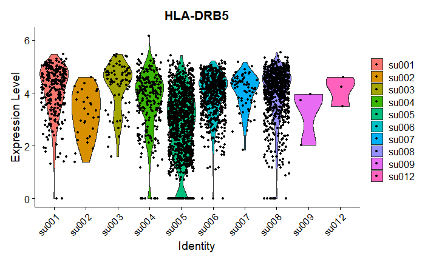

Conduct ANOVA tests

```r
grid.arrange(`hla.anova.plotsHLA-A`, `hla.anova.plotsHLA-B`)
```

```
Error in gList(list(pairlist(pairlist(.Primitive(".External2"), pairlist(list( :
  only 'grobs' allowed in "gList"
```

Analyze MHC I/II genes together

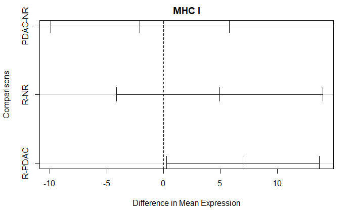

```
Error in gList(list(wrapvp = list(x = 0.5, y = 0.5, width = 1, height = 1,  :
  only 'grobs' allowed in "gList"
```

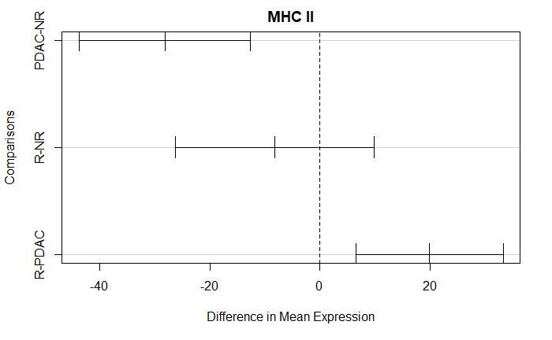

```r
grid.arrange(tuk_plot(mhc1.tukey, title = "MHC I"), tuk_plot(mhc2.tukey, title = "MHC II"), ncol=2)
```

Check MHC scores for malignant cell populations

```r
Idents(BCCIO) <- BCCIO$seurat_clusters
bcc.malignant <- subset(BCCIO, idents = c("Macrophages", "Tumor 1", "Tumor 2"))

Idents(PDAC155698.integrated) <- PDAC155698.integrated$seurat_clusters
PDAC.subset <- subset(PDAC155698.integrated, idents = c("Acinar cells", "Epithelial + Endocrine"))
```

```
Error in subCsp_ij(x, i, j, drop = drop) :
  Cholmod error 'out of memory' at file ../Core/cholmod_memory.c, line 146
```

HSP Genes Differential Expression: Responders vs. PDAC

HSP Genes Differential Expression: Responders vs. Nonresponders

HSP Score Analysis

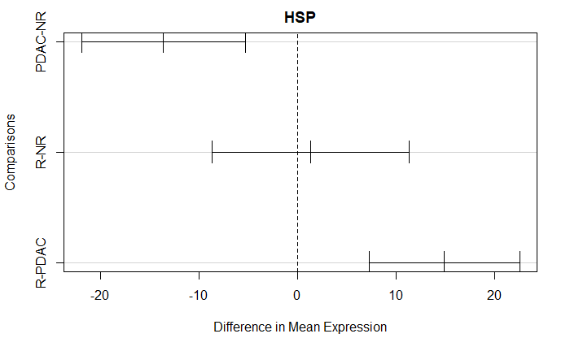

HSP Score Analysis: Malignant Cells

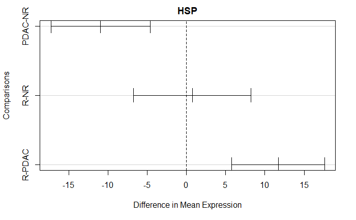

Compare pretreatment PDAC to BCC responders and nonresponders, pretreatment vs. posttreatment

```r
## Possible comparisons: CD8+ T cells, CD4+ T cells, Tregs, B cells, Macrophages, NK cells

BCC.PDAC.comparison.CD8 <- fiveway_diffexpression_MHCandHSP(c("CD8_activation", "CD8_exhausted", "CD8_memory"), "CD8+ T cells", "CD8+ T Cells")
BCC.PDAC.comparison.CD4 <- fiveway_diffexpression_MHCandHSP("CD4", "CD4+ T cells", "CD4+ T Cells")
BCC.PDAC.comparison.Tregs <- fiveway_diffexpression_MHCandHSP("Tregs", "Tregs", "Regulatory T Cells")
BCC.PDAC.comparison.Macrophages <- fiveway_diffexpression_MHCandHSP("Macrophages", "Macrophages", "Macrophages")
BCC.PDAC.comparison.B <- fiveway_diffexpression_MHCandHSP("B cells", "B cells","B Cells")
BCC.PDAC.comparison.NK <- fiveway_diffexpression_MHCandHSP("NK", "NK cells", "Natural Killer Cells")

## Use grid.draw() to see the final product
```

Look at expression of PD-1 pathway again

```r
Idents(PDAC155698.integrated) <- PDAC155698.integrated$seurat_clusters

PDAC.averages <- AverageExpression(PDAC155698.integrated)[["RNA"]]
PDAC.genes <- rownames(PDAC.averages)

PDAC.averages.PD1 <- PDAC.averages[c("PDCD1", "CD274", "PDCD1LG2"),]

Idents(BCC.responder.pre) <- BCC.responder.pre$seurat_clusters
Idents(BCC.responder.post) <- BCC.responder.post$seurat_clusters
Idents(BCC.nonresponder.pre) <- BCC.nonresponder.pre$seurat_clusters
Idents(BCC.nonresponder.post) <- BCC.nonresponder.post$seurat_clusters

BCC.responder.pre.averages <- AverageExpression(BCC.responder.pre)[["RNA"]]
BCC.responder.post.averages <- AverageExpression(BCC.responder.post)[["RNA"]]
BCC.nonresponder.pre.averages <- AverageExpression(BCC.nonresponder.pre)[["RNA"]]
BCC.nonresponder.post.averages <- AverageExpression(BCC.nonresponder.post)[["RNA"]]

BCC.responder.pre.averages.PD1 <- BCC.responder.pre.averages[c("PDCD1", "CD274", "PDCD1LG2"),]
BCC.responder.post.averages.PD1 <- BCC.responder.post.averages[c("PDCD1", "CD274", "PDCD1LG2"),]
BCC.nonresponder.pre.averages.PD1 <- BCC.nonresponder.pre.averages[c("PDCD1", "CD274", "PDCD1LG2"),]
BCC.nonresponder.post.averages.PD1 <- BCC.nonresponder.post.averages[c("PDCD1", "CD274", "PDCD1LG2"),]
```

Complete analysis using reclustered PDAC dataset

Compare malignant cells between PDAC and BCC

```r
## Create merged BCC and PDAC object

Idents(BCCIO) <- BCCIO$seurat_clusters
Idents(PDAC.integrated) <- PDAC.integrated$seurat_clusters

PDAC.malignant <- subset(PDAC.integrated, idents=c("Ductal cells 1", "Ductal cells 2", "Ductal cells 3", "Ductal cells 4"))

BCC.malignant <- subset(BCCIO, idents=c("Tumor 1", "Tumor 2"))

BCC.PDAC.malignant <- merge(PDAC.malignant, BCC.malignant, add.cell.ids = c("PDAC", "BCC"))

BCC.PDAC.malignant@meta.data$sort <- NULL
BCC.PDAC.malignant@meta.data$RNA_snn_res.0.5 <- NULL
BCC.PDAC.malignant@meta.data$RNA_snn_res.0.4 <- NULL

BCC.PDAC.malignant@meta.data$response[is.na(BCC.PDAC.malignant@meta.data$response)] <- "PDAC"
BCC.PDAC.malignant@meta.data$treatment[is.na(BCC.PDAC.malignant@meta.data$treatment)] <- "PDAC"
BCC.PDAC.malignant@meta.data$celltype <- "Malignant cells"

## Enhanced volcano plot comparing PDAC to all BCC

Idents(BCC.PDAC.malignant) <- BCC.PDAC.malignant$celltype

BCC.PDAC.malignant.volcano <- bioc_volcano(BCC.PDAC.malignant, celltype = "Malignant cells", group = "response", ident = "PDAC", ident2 = "BCC", title = "PDAC vs. BCC (All)")

## Enhanced volcano plot comparing PDAC to all BCC pretreatment

Idents(BCC.PDAC.malignant) <- BCC.PDAC.malignant$treatment

BCC.PDAC.malignant.pre <- subset(BCC.PDAC.malignant, idents = c("pre", "PDAC"))

Idents(BCC.PDAC.malignant.pre) <- BCC.PDAC.malignant.pre$celltype

BCC.PDAC.malignant.pre.volcano <- bioc_volcano(BCC.PDAC.malignant.pre, celltype = "Malignant cells", group = "response", ident = "PDAC", ident2 = "BCC", title = "PDAC vs. BCC Pretreatment")

## Enhanced volcano plot comparing PDAC to BCC responders pretreatment

Idents(BCC.PDAC.malignant.pre) <- BCC.PDAC.malignant.pre$response

BCC.PDAC.malignant.preresponder <- subset(BCC.PDAC.malignant.pre, idents = c("Responsive", "PDAC"))

BCC.PDAC.malignant.preresponder.volcano <- bioc_volcano(BCC.PDAC.malignant.preresponder, celltype = "Malignant cells", group = "response", ident = "PDAC", ident2 = "BCC", title = "PDAC vs. BCC Responders Pretreatment")
```

Calculate MHC Class I scores for PDAC and BCC

```r
## Calculate scores by patient

Idents(BCC.PDAC.malignant.pre) <- BCC.PDAC.malignant.pre$response
Idents(BCC.PDAC.malignant) <- BCC.PDAC.malignant$response


## Dot plots (by gene, by cluster)

mhc.genes <- c('HLA-A', 'HLA-B', 'HLA-C', 'HLA-E', 'HLA-F', 'HLA-G', 'HLA-DMA', 'HLA-DMB', 'HLA-DOA', 'HLA-DPA1', 'HLA-DPB1', 'HLA-DQA1', 'HLA-DQA2', 'HLA-DQB1', 'HLA-DQB2', 'HLA-DRA', 'HLA-DRB1', 'HLA-DRB5')

BCC.PDAC.malignant.expression <- AverageExpression(BCC.PDAC.malignant)
BCC.PDAC.malignant.mhc.expression <- BCC.PDAC.malignant.expression[["RNA"]][mhc.genes,]

BCC.PDAC.malignant.mhc.expression$Gene <- rownames(BCC.PDAC.malignant.mhc.expression)
BCC.PDAC.malignant.mhc.expression <- melt(BCC.PDAC.malignant.mhc.expression, id.vars="Gene")

BCC.PDAC.malignant.mhc.dotplot <- ggplot(BCC.PDAC.malignant.mhc.expression, aes(x=Gene, y=value, color=variable)) +
  geom_dotplot(binaxis='y', stackdir='center', binwidth=0) +
  theme_light() +
  coord_flip() +
  labs(title = "Average Expression of MHC Genes", x = "Score", y = "Gene") +
  geom_point(aes(size=3))

BCC.PDAC.malignant.mhc.dotplot

## Dumbbell plots (by gene, by patient)

BCC.PDAC.malignant@meta.data$cancer <- BCC.PDAC.malignant@meta.data$response
Idents(BCC.PDAC.malignant) <- BCC.PDAC.malignant$cancer

BCC.PDAC.malignant <- RenameIdents(object = BCC.PDAC.malignant,
                                   "PDAC" = "PDAC",
                                   "Responsive" = "BCC",
                                   "Nonresponsive" = "BCC")
BCC.PDAC.malignant@meta.data$cancer <- Idents(BCC.PDAC.malignant)

BCC.PDAC.malignant.expression.cancer <- AverageExpression(BCC.PDAC.malignant)
BCC.PDAC.malignant.mhc.expression.cancer <- data.frame(t(BCC.PDAC.malignant.expression.cancer[["RNA"]][mhc.genes,]))
colnames(BCC.PDAC.malignant.mhc.expression.cancer) <- mhc.genes

BCC.PDAC.malignant.mhc.expression.cancer$Cancer <- rownames(BCC.PDAC.malignant.mhc.expression.cancer)
BCC.PDAC.malignant.mhc.expression.cancer <- melt(BCC.PDAC.malignant.mhc.expression.cancer, id.vars="Cancer")

BCC.PDAC.malignant.mhc.expression.cancer <- BCC.PDAC.malignant.mhc.expression.cancer %>%
  mutate(paired = rep(1:(n()/2), each=2), Cancer=factor(Cancer))

BCC.PDAC.malignant.mhc.expression.cancer %>% ggplot(aes(x=value, y=variable)) +
  geom_line(aes(group=paired)) +
  geom_point(aes(color=Cancer), size=5) +
  theme(legend.position="top") +
  labs(title = "Average Expression of MHC Genes", x = "Score", y = "Gene") +
  theme_light() +
  theme(legend.position="top", plot.title = element_text(color="black", size=18, face="bold", hjust = 0.5))

## Calculate MHC Class I and II scores

mhc1.genes <- c('HLA-A', 'HLA-B', 'HLA-C', 'HLA-E', 'HLA-F', 'HLA-G')
mhc2.genes <- c('HLA-DMA', 'HLA-DMB', 'HLA-DOA', 'HLA-DPA1', 'HLA-DPB1', 'HLA-DQA1', 'HLA-DQA2', 'HLA-DQB1', 'HLA-DQB2', 'HLA-DRA', 'HLA-DRB1', 'HLA-DRB5')

BCC.PDAC.malignant.mhc1.expression.cancer <- BCC.PDAC.malignant.expression.cancer[["RNA"]][mhc1.genes,]
BCC.PDAC.malignant.mhc2.expression.cancer <- BCC.PDAC.malignant.expression.cancer[["RNA"]][mhc2.genes,]

avg1 <- t(data.frame(colMeans(BCC.PDAC.malignant.mhc1.expression.cancer)))
BCC.PDAC.malignant.mhc1.expression.cancer <- rbind(BCC.PDAC.malignant.mhc1.expression.cancer, avg1)

avg2 <- t(data.frame(colMeans(BCC.PDAC.malignant.mhc2.expression.cancer)))
BCC.PDAC.malignant.mhc2.expression.cancer <- rbind(BCC.PDAC.malignant.mhc2.expression.cancer, avg2)

BCC.PDAC.malignant.mhc.expression.cancer <- rbind(BCC.PDAC.malignant.mhc1.expression.cancer, BCC.PDAC.malignant.mhc2.expression.cancer)

rownames(BCC.PDAC.malignant.mhc.expression.cancer)[rownames(BCC.PDAC.malignant.mhc.expression.cancer) == "colMeans.BCC.PDAC.malignant.mhc1.expression.cancer."] <- "MHC Class I"
rownames(BCC.PDAC.malignant.mhc.expression.cancer)[rownames(BCC.PDAC.malignant.mhc.expression.cancer) == "colMeans.BCC.PDAC.malignant.mhc2.expression.cancer."] <- "MHC Class II"

BCC.PDAC.malignant.mhc.expression.cancer <- data.frame(t(BCC.PDAC.malignant.mhc.expression.cancer))

# Execute 1198 - 1210

## Recreate dumbbell plots with both responders and nonresponders

Idents(BCC.PDAC.malignant) <- BCC.PDAC.malignant$response

BCC.PDAC.malignant.averages.response <- AverageExpression(BCC.PDAC.malignant)
BCC.PDAC.malignant.averages.response.mhc1 <- BCC.PDAC.malignant.averages.response[["RNA"]][mhc1.genes,]
BCC.PDAC.malignant.averages.response.mhc2 <- BCC.PDAC.malignant.averages.response[["RNA"]][mhc2.genes,]

avg1 <- t(data.frame(colMeans(BCC.PDAC.malignant.averages.response.mhc1)))
BCC.PDAC.malignant.averages.response.mhc1 <- rbind(BCC.PDAC.malignant.averages.response.mhc1, avg1)

avg2 <- t(data.frame(colMeans(BCC.PDAC.malignant.averages.response.mhc2)))
BCC.PDAC.malignant.averages.response.mhc2 <- rbind(BCC.PDAC.malignant.averages.response.mhc2, avg2)

BCC.PDAC.malignant.averages.response.mhc <- rbind(BCC.PDAC.malignant.averages.response.mhc1, BCC.PDAC.malignant.averages.response.mhc2)

rownames(BCC.PDAC.malignant.averages.response.mhc)[rownames(BCC.PDAC.malignant.averages.response.mhc) == "colMeans.BCC.PDAC.malignant.averages.response.mhc1."] <- "MHC Class I"
rownames(BCC.PDAC.malignant.averages.response.mhc)[rownames(BCC.PDAC.malignant.averages.response.mhc) == "colMeans.BCC.PDAC.malignant.averages.response.mhc2."] <- "MHC Class II"

BCC.PDAC.malignant.averages.response.mhc <- data.frame(t(BCC.PDAC.malignant.averages.response.mhc))

BCC.PDAC.malignant.averages.response.mhc$Response <- rownames(BCC.PDAC.malignant.averages.response.mhc)
BCC.PDAC.malignant.averages.response.mhc <- melt(BCC.PDAC.malignant.averages.response.mhc, id.vars="Response")

BCC.PDAC.malignant.averages.response.mhc <- BCC.PDAC.malignant.averages.response.mhc %>%
  mutate(paired = rep(1:(n()/3), each=3), Response=factor(Response))

BCC.PDAC.malignant.averages.response.mhc %>% ggplot(aes(x=value, y=variable)) +
  geom_line(aes(group=paired)) +
  geom_point(aes(color=Response), size=5) +
  theme(legend.position="top") +
  labs(title = "Average Expression of MHC Genes", x = "Score", y = "Gene") +
  theme_light() +
  theme(legend.position="top", plot.title = element_text(color="black", size=18, face="bold", hjust = 0.5))

## Recreate dumbbell plots, separating pretreatment and posttreatment

BCC.PDAC.malignant$restreat <- "PDAC"
BCC.PDAC.malignant$restreat[BCC.PDAC.malignant$treatment == "pre" & BCC.PDAC.malignant$response == "Responsive"] <- "Responsive Pretreatment"
BCC.PDAC.malignant$restreat[BCC.PDAC.malignant$treatment == "post" & BCC.PDAC.malignant$response == "Responsive"] <- "Responsive Posttreatment"
BCC.PDAC.malignant$restreat[BCC.PDAC.malignant$treatment == "pre" & BCC.PDAC.malignant$response == "Nonresponsive"] <- "Nonresponsive Pretreatment"
BCC.PDAC.malignant$restreat[BCC.PDAC.malignant$treatment == "post" & BCC.PDAC.malignant$response == "Nonresponsive"] <- "Nonresponsive Posttreatment"

Idents(BCC.PDAC.malignant) <- BCC.PDAC.malignant$restreat

BCC.PDAC.malignant.averages.restreat <- AverageExpression(BCC.PDAC.malignant)
BCC.PDAC.malignant.averages.restreat.mhc1 <- BCC.PDAC.malignant.averages.restreat[["RNA"]][mhc1.genes,]
BCC.PDAC.malignant.averages.restreat.mhc2 <- BCC.PDAC.malignant.averages.restreat[["RNA"]][mhc2.genes,]

avg1 <- t(data.frame(colMeans(BCC.PDAC.malignant.averages.restreat.mhc1)))
BCC.PDAC.malignant.averages.restreat.mhc1 <- rbind(BCC.PDAC.malignant.averages.restreat.mhc1, avg1)

avg2 <- t(data.frame(colMeans(BCC.PDAC.malignant.averages.restreat.mhc2)))
BCC.PDAC.malignant.averages.restreat.mhc2 <- rbind(BCC.PDAC.malignant.averages.restreat.mhc2, avg2)

BCC.PDAC.malignant.averages.restreat.mhc <- rbind(BCC.PDAC.malignant.averages.restreat.mhc1, BCC.PDAC.malignant.averages.restreat.mhc2)

rownames(BCC.PDAC.malignant.averages.restreat.mhc)[rownames(BCC.PDAC.malignant.averages.restreat.mhc) == "colMeans.BCC.PDAC.malignant.averages.restreat.mhc1."] <- "MHC Class I"
rownames(BCC.PDAC.malignant.averages.restreat.mhc)[rownames(BCC.PDAC.malignant.averages.restreat.mhc) == "colMeans.BCC.PDAC.malignant.averages.restreat.mhc2."] <- "MHC Class II"

BCC.PDAC.malignant.averages.restreat.mhc <- data.frame(t(BCC.PDAC.malignant.averages.restreat.mhc))

BCC.PDAC.malignant.averages.restreat.mhc$Response <- rownames(BCC.PDAC.malignant.averages.restreat.mhc)
BCC.PDAC.malignant.averages.restreat.mhc <- melt(BCC.PDAC.malignant.averages.restreat.mhc, id.vars="Response")

BCC.PDAC.malignant.averages.restreat.mhc <- BCC.PDAC.malignant.averages.restreat.mhc %>%
  mutate(paired = rep(1:(n()/5), each=5), Response=factor(Response))

BCC.PDAC.malignant.averages.restreat.mhc %>% ggplot(aes(x=value, y=variable)) +
  geom_line(aes(group=paired)) +
  geom_point(aes(color=Response), size=5) +
  theme(legend.position="top") +
  labs(title = "Average Expression of MHC Genes", x = "Score", y = "Gene") +
  theme_light() +
  theme(legend.position="top", plot.title = element_text(color="black", size=18, face="bold", hjust = 0.5))
```

Investigate MHC expression in different clusters and patients

```r
BCC.PDAC.malignant <- preprocessing(BCC.PDAC.malignant)
BCC.PDAC.malignant <- clustering(BCC.PDAC.malignant, resolution=0.5)

BCC.PDAC.malignant$clusters <- save$seurat_clusters
Idents(BCC.PDAC.malignant) <- BCC.PDAC.malignant$clusters
DimPlot(BCC.PDAC.malignant, reduction = "umap")

Idents(BCC.PDAC.malignant) <- BCC.PDAC.malignant$seurat_clusters
BCC.PDAC.malignant.averages <- AverageExpression(BCC.PDAC.malignant, return.seurat=TRUE, add.ident="restreat")

mhc.genes <- c(mhc1.genes, mhc2.genes)

BCC.PDAC.mhc.heatmap <- DoHeatmap(BCC.PDAC.malignant.averages, features=mhc.genes, size=3, draw.lines=FALSE)

BCC.PDAC.heatmap <- DoHeatmap(BCC.PDAC.malignant.averages, features = unlist(TopFeatures(BCC.PDAC.malignant[['pca']], balanced=TRUE)), size=3, draw.lines=FALSE)
BCC.PDAC.heatmap

## Investigate expression per patient

Idents(BCC.PDAC.malignant) <- BCC.PDAC.malignant$response

BCC.PDAC.malignant.averages <- AverageExpression(BCC.PDAC.malignant, return.seurat=TRUE, add.ident="patient")
BCC.PDAC.patient.heatmap <- DoHeatmap(BCC.PDAC.malignant.averages, features=mhc.genes, size=3, draw.lines=TRUE)

Idents(BCC.PDAC.malignant) <- BCC.PDAC.malignant$treatment
BCC.PDAC.malignant.pre <- subset(BCC.PDAC.malignant, idents=c("PDAC", "pre"))

Idents(BCC.PDAC.malignant.pre) <- BCC.PDAC.malignant.pre$response
BCC.PDAC.malignant.pre.averages <- AverageExpression(BCC.PDAC.malignant.pre, return.seurat=TRUE, add.ident="patient")
BCC.PDAC.pre.patient.heatmap <- DoHeatmap(BCC.PDAC.malignant.pre.averages, features=mhc.genes, size=3, draw.lines=TRUE)

## Throw out patient 1

Idents(BCC.PDAC.malignant) <- BCC.PDAC.malignant$patient
BCC.PDAC.malignant.p1 <- subset(BCC.PDAC.malignant, idents="pdac1", invert=TRUE)

Idents(BCC.PDAC.malignant.p1) <- BCC.PDAC.malignant.p1$response
BCC.PDAC.malignant.p1.averages <- AverageExpression(BCC.PDAC.malignant.p1, return.seurat=TRUE, add.ident="patient")
BCC.PDAC.patient.p1.heatmap <- DoHeatmap(BCC.PDAC.malignant.p1.averages, features=mhc.genes, size=3, draw.lines=TRUE)

Idents(BCC.PDAC.malignant.p1) <- BCC.PDAC.malignant.p1$treatment
BCC.PDAC.malignant.p1.pre <- subset(BCC.PDAC.malignant.p1, idents=c("PDAC", "pre"))

Idents(BCC.PDAC.malignant.p1.pre) <- BCC.PDAC.malignant.p1.pre$response
BCC.PDAC.malignant.p1.pre.averages <- AverageExpression(BCC.PDAC.malignant.p1.pre, return.seurat=TRUE, add.ident="patient")
BCC.PDAC.patient.p1.pre.heatmap <- DoHeatmap(BCC.PDAC.malignant.p1.pre.averages, features=mhc.genes, size=3, draw.lines=TRUE)

## Separate by patient and treatment

Idents(BCC.PDAC.malignant) <- BCC.PDAC.malignant$treatment
BCC.malignant <- subset(BCC.PDAC.malignant, idents=c("pre", "post"))

Idents(BCC.malignant) <- BCC.malignant$patient
BCC.malignant.averages <- AverageExpression(BCC.malignant, return.seurat=TRUE, add.ident="treatment")

BCC.malignant.averages.mhc1 <- data.frame(BCC.malignant.averages[["RNA"]][mhc1.genes,])
BCC.malignant.averages.mhc2 <- data.frame(BCC.malignant.averages[["RNA"]][mhc2.genes,])

BCC.malignant.averages.mhc1$su001_post <- 0
BCC.malignant.averages.mhc1$su002_post <- 0
BCC.malignant.averages.mhc1$su010_pre <- 0

BCC.malignant.averages.mhc2$su001_post <- 0
BCC.malignant.averages.mhc2$su002_post <- 0
BCC.malignant.averages.mhc2$su010_pre <- 0

BCC.malignant.averages.mhc1 <- BCC.malignant.averages.mhc1[, c(1, 16, 2, 17, 3, 4, 5, 6, 7, 8, 9, 10, 11, 12, 13, 14, 18, 15)]
BCC.malignant.averages.mhc2 <- BCC.malignant.averages.mhc2[, c(1, 16, 2, 17, 3, 4, 5, 6, 7, 8, 9, 10, 11, 12, 13, 14, 18, 15)]

avg1 <- t(data.frame(colMeans(BCC.malignant.averages.mhc1)))
avg2 <- t(data.frame(colMeans(BCC.malignant.averages.mhc2)))

BCC.malignant.averages.mhc <- rbind(avg1, avg2)

BCC.malignant.averages.mhc.pre <- BCC.malignant.averages.mhc[, c(1, 3, 5, 7, 9, 11, 13, 15, 17)]
BCC.malignant.averages.mhc.post <- BCC.malignant.averages.mhc[, c(2, 4, 6, 8, 10, 12, 14, 16, 18)]
colnames(BCC.malignant.averages.mhc.pre) <- c('su001', 'su002', 'su003', 'su004', 'su005', 'su006', 'su007', 'su008', 'su010')
rownames(BCC.malignant.averages.mhc.pre) <- c('MHC Class 1 Pre-treatment', 'MHC Class 2 Pre-treatment')
colnames(BCC.malignant.averages.mhc.post) <- c('su001', 'su002', 'su003', 'su004', 'su005', 'su006', 'su007', 'su008', 'su010')
rownames(BCC.malignant.averages.mhc.post) <- c('MHC Class 1 Post-treatment', 'MHC Class 2 Post-treatment')
BCC.malignant.averages.mhc <- data.frame(rbind(BCC.malignant.averages.mhc.pre, BCC.malignant.averages.mhc.post))

save <- BCC.malignant.averages.mhc

BCC.malignant.averages.mhc$Response <- rownames(BCC.malignant.averages.mhc)
BCC.malignant.averages.mhc <- melt(BCC.malignant.averages.mhc, id.vars="Response")

BCC.malignant.averages.mhc <- BCC.malignant.averages.mhc %>%
  mutate(paired = rep(1:(n()/4), each=4), Response=factor(Response))

BCC.malignant.averages.mhc %>% ggplot(aes(x=value, y=variable)) +
  geom_line(aes(group=paired)) +
  geom_point(aes(color=Response), size=5) +
  theme(legend.position="top") +
  labs(title = "Average Expression of MHC Genes", x = "Score", y = "Patient") +
  theme_light() +
  theme(legend.position="top", plot.title = element_text(color="black", size=18, face="bold", hjust = 0.5))

## Five-way boxplot to compare MHC scores

BCCIO$restreat <- "filler"

BCCIO$restreat[BCCIO$treatment == "pre" & BCCIO$response == "Responsive"] <- "Responsive Pretreatment"
BCCIO$restreat[BCCIO$treatment == "post" & BCCIO$response == "Responsive"] <- "Responsive Posttreatment"
BCCIO$restreat[BCCIO$treatment == "pre" & BCCIO$response == "Nonresponsive"] <- "Nonresponsive Pretreatment"
BCCIO$restreat[BCCIO$treatment == "post" & BCCIO$response == "Nonresponsive"] <- "Nonresponsive Posttreatment"

Idents(BCCIO) <- BCCIO$restreat

BCC.responder.pre <- subset(BCCIO, idents="Responsive Pretreatment")
BCC.responder.post <- subset(BCCIO, idents="Responsive Posttreatment")
BCC.nonresponder.pre <- subset(BCCIO, idents="Nonresponsive Pretreatment")
BCC.nonresponder.post <- subset(BCCIO, idents="Nonresponsive Posttreatment")

PDAC155698.integrated <- PDAC.integrated

Idents(BCCIO) <- BCCIO$seurat_clusters
Idents(PDAC155698.integrated) <- PDAC155698.integrated$seurat_clusters

BCC.PDAC.comparison.malignant <- fiveway_diffexpression_MHCandHSP(c("Tumor 1", "Tumor 2"), c("Ductal cells 1", "Ductal cells 2", "Ductal cells 3", "Ductal cells 4"), "Malignant Cells")
grid.draw(BCC.PDAC.comparison.malignant)
```

Compare gene expression between malignnat cells in BCC vs. PDAC

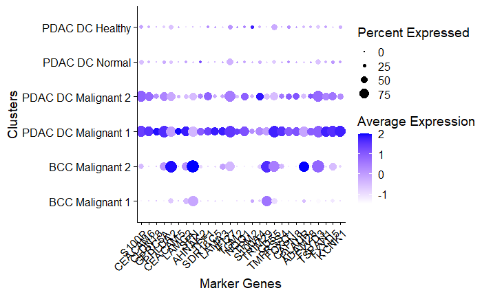

Investigate MHC expression between BCC and PDAC

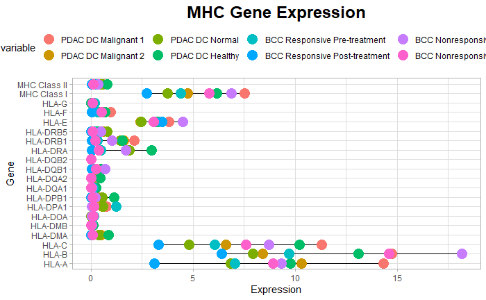

Look at MHC gene expression by individual cell

```r
mhc2.cdf.data <- data.frame(MHC.Class.II, id)
```

```
Error in data.frame(MHC.Class.II, id) : object 'MHC.Class.II' not found
```

Look at per-patient MHC scores

[figure not shown]

Statistical comparison of MHC Class I and Class II scores, calculated by patient

```r
## Construct boxplot

clusters <- list(`malignant.PDAC M1`, `malignant.PDAC M2`, `malignant.PDAC N`, `malignant.PDAC H`, `malignant.BCC RPre`, `malignant.BCC RPost`, `malignant.BCC NRPre`, `malignant.BCC NRPost`)

clusternames <- c('PDAC.M1','PDAC.M2', 'PDAC.N', 'PDAC.H', 'BCC.RPre', 'BCC.RPost', 'BCC.NRPre', 'BCC.NRPost')

pdacclusters <- list(`malignant.PDAC M1`, `malignant.PDAC M2`, `malignant.PDAC N`, `malignant.PDAC H`)

for (i in 1:length(pdacclusters)) {
  clusters[[i]]$patient <- clusters[[i]]$orig.ident
}

for (i in 1:length(clusters)) {
  Idents(clusters[[i]]) <- clusters[[i]]$patient
  assign(paste0(clusternames[i], ".exp"), AverageExpression(clusters[[i]]))
}

cluster.averages <- list(PDAC.M1.exp, PDAC.M2.exp, PDAC.N.exp, PDAC.H.exp, BCC.RPre.exp, BCC.RPost.exp, BCC.NRPre.exp, BCC.NRPost.exp)

for (i in 1:length(cluster.averages)) {
  assign(paste0(clusternames[i], ".exp.mhc1"), cluster.averages[[i]]$RNA[mhc1.genes, ])
  assign(paste0(clusternames[i], ".exp.mhc2"), cluster.averages[[i]]$RNA[mhc2.genes, ])
}

cluster.averages.mhc1 <- list(PDAC.M1.exp.mhc1, PDAC.M2.exp.mhc1, PDAC.N.exp.mhc1, PDAC.H.exp.mhc1, BCC.RPre.exp.mhc1, BCC.RPost.exp.mhc1, BCC.NRPre.exp.mhc1, BCC.NRPost.exp.mhc1)

cluster.averages.mhc2 <- list(PDAC.M1.exp.mhc2, PDAC.M2.exp.mhc2, PDAC.N.exp.mhc2, PDAC.H.exp.mhc2, BCC.RPre.exp.mhc2, BCC.RPost.exp.mhc2, BCC.NRPre.exp.mhc2, BCC.NRPost.exp.mhc2)

for (i in 1:length(cluster.averages.mhc1)) {
  cluster.averages.mhc1[[i]] <- as.data.frame(colMeans(cluster.averages.mhc1[[i]]))
  cluster.averages.mhc1[[i]]$patient <- rownames(cluster.averages.mhc1[[i]])
  cluster.averages.mhc1[[i]]$cluster <- clusternames[i]
  colnames(cluster.averages.mhc1[[i]]) <- c("score", "patient", "cluster")
}

for (i in 1:length(cluster.averages.mhc2)) {
  cluster.averages.mhc2[[i]] <- as.data.frame(colMeans(cluster.averages.mhc2[[i]]))
  cluster.averages.mhc2[[i]]$patient <- rownames(cluster.averages.mhc2[[i]])
  cluster.averages.mhc2[[i]]$cluster <- clusternames[i]
  colnames(cluster.averages.mhc2[[i]]) <- c("score", "patient", "cluster")
}

cluster.averages.mhc1 <- rbind(cluster.averages.mhc1[[1]], cluster.averages.mhc1[[2]], cluster.averages.mhc1[[3]], cluster.averages.mhc1[[4]], cluster.averages.mhc1[[5]], cluster.averages.mhc1[[6]], cluster.averages.mhc1[[7]], cluster.averages.mhc1[[8]])

cluster.averages.mhc2 <- rbind(cluster.averages.mhc2[[1]], cluster.averages.mhc2[[2]], cluster.averages.mhc2[[3]], cluster.averages.mhc2[[4]], cluster.averages.mhc2[[5]], cluster.averages.mhc2[[6]], cluster.averages.mhc2[[7]], cluster.averages.mhc2[[8]])

comparisons <- list(c("BCC.RPre", "BCC.RPost"), c("BCC.NRPre", "BCC.NRPost"), c("BCC.RPre", "BCC.NRPre"), c("BCC.RPost", "BCC.NRPost"), c("PDAC.M1", "BCC.RPre"), c("PDAC.M1", "BCC.NRPre"), c("PDAC.M2", "BCC.RPre"), c("PDAC.M2", "BCC.NRPre"))

mhc1.score.comparison <- ggboxplot(cluster.averages.mhc1, x="cluster", y="score", color="cluster", title="MHC Class I Score", add="jitter") +
  stat_compare_means(comparisons = comparisons) +
  theme(legend.position="none", plot.title = element_text(color="black", size=18, face="bold", hjust = 0.5))

mhc2.score.comparison <- ggboxplot(cluster.averages.mhc2, x="cluster", y="score", color="cluster", title="MHC Class II Score", add="jitter") +
  stat_compare_means(comparisons = comparisons) +
  theme(legend.position="none", plot.title = element_text(color="black", size=18, face="bold", hjust = 0.5))
```

Comparison of MHC Class I scores based on percentage of malignant cells

```r
hc2.levels.data <- malignant.levels.mhc2.cdf$data
colnames(mhc2.levels.data) <- c("MHC Class II", "Proportion")
```

```
Error in names(x) <- value :
  'names' attribute [2] must be the same length as the vector [1]
```

Examine differences in expression of the PD-1 pathway

```r
Idents(BCC.pre.NR) <- BCC.pre.NR$seurat_clusters
Idents(BCC.pre.NR) <- BCC.pre.NR$seurat_clusters
for (i in 1:length(bcc.clusters)) {
  assign(paste0("bcc.preR", bcc.clusters[i]), subset(BCC.pre.R, idents=bcc.clusters[i]))
  assign(paste0("bcc.preNR", bcc.clusters[i]), subset(BCC.pre.NR, idents=bcc.clusters[i]))
  print(bcc.clusters[i])
}
```

```
[1] "CD8_memory"
[1] "CD4"
[1] "B cells"
[1] "Tregs"
[1] "CD8_activation"
[1] "CD8_exhausted"
[1] "Macrophages"
[1] "Plasma"
[1] "Tumor 1"
[1] "Misc."
[1] "T_proliferation"
[1] "CAFs"
```

```
[1] "NK"
[1] "pDCs"
[1] "Tumor 2"
[1] "Endothelial"
[1] "DCs"
[1] "Myofibroblasts"
[1] "Melanocytes"
```

Differential gene expression between BCC and PDAC: PD-1 pathway

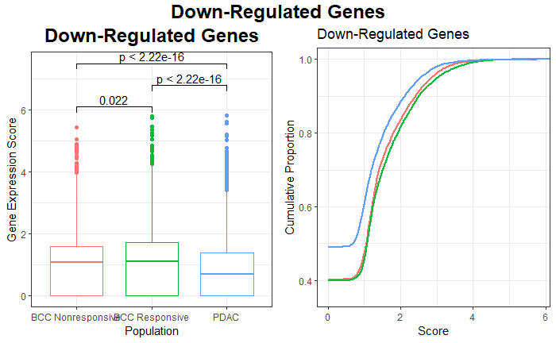